# Stage 2 — Method, Plan, Computation Code and Output (individual assignment #2)

**Dataset:** UCI *Online Shoppers Purchasing Intention* (ID 468)  
**Student Name:** Antong Liu  
**Student Number:** 27899913  
**Group:** 24  
**Date:** 2025-10-25

```python
# ---------- Setup ----------
# If running in a clean environment, uncomment to install.
#%pip install -q ucimlrepo pandas matplotlib seaborn
#%pip install -q scikit-learn

import re
import numpy as np
import pandas as pd
import matplotlib.pyplot as plt
import seaborn as sns

pd.set_option("display.max_colwidth", 120)
pd.set_option("display.width", 120)
sns.set(context="notebook", style="whitegrid")
```

## Section 0: TA Feedback (Stage 1)

- **Score:** 25 / 30
- **Mechanics:** 3/3 — Good structure and code.
- **Reasoning:** 9/12 — *TA comment:* "Need more written data description."
- **Writing:** 3/3 — No major grammar issues.
- **Visualization:** 10/12 — *TA comment:* "plot can be clearer - legend overlaps certain part of the plot, x-axis label has underscore; you can also compare with a box plot with only revenue and exit rates (to confirm your interpretation). overall good job"

### Actions Taken (Revisions Highlighted in Yellow)

- Expanded the **data description** by adding written definitions for all 18 variables, using the original paper and UCI documentation as references.
- Improved the **main visualization** by reducing legend size and adjusting axis labels (e.g., removing underscores) so the plot is clearer and easier to read.
- Refined the **interpretation of the boxplot** to focus more directly on how `ExitRates` differ by `Revenue` and `VisitorType`, in line with the TA’s suggestion about comparing exit behavior and purchase outcomes.

## Section 1: Data Description

### 1.1 Load the dataset (UCI ID 468) & exclude Region 1

```python
from ucimlrepo import fetch_ucirepo

ospi = fetch_ucirepo(id=468)
df = pd.concat([ospi.data.features, ospi.data.targets], axis=1)

print(f"Original shape: {df.shape}")

df = df[df["Region"] != 1].copy()

print(f"After excluding Region == 1: {df.shape}")
df.head()
```

```
Original shape: (12330, 18)
After excluding Region == 1: (7550, 18)
```

|  | Administrative | Administrative_Duration | Informational | Informational_Duration | ProductRelated | ProductRelated_Duration | BounceRates | ExitRates | PageValues | SpecialDay | Month | OperatingSystems | Browser | Region | TrafficType | VisitorType | Weekend | Revenue |
| --- | --- | --- | --- | --- | --- | --- | --- | --- | --- | --- | --- | --- | --- | --- | --- | --- | --- | --- |
| 2 | 0 | 0.0 | 0 | 0.0 | 1 | 0.000000 | 0.20 | 0.200000 | 0.0 | 0.0 | Feb | 4 | 1 | 9 | 3 | Returning_Visitor | False | False |
| 3 | 0 | 0.0 | 0 | 0.0 | 2 | 2.666667 | 0.05 | 0.140000 | 0.0 | 0.0 | Feb | 3 | 2 | 2 | 4 | Returning_Visitor | False | False |
| 6 | 0 | 0.0 | 0 | 0.0 | 1 | 0.000000 | 0.20 | 0.200000 | 0.0 | 0.4 | Feb | 2 | 4 | 3 | 3 | Returning_Visitor | False | False |
| 8 | 0 | 0.0 | 0 | 0.0 | 2 | 37.000000 | 0.00 | 0.100000 | 0.0 | 0.8 | Feb | 2 | 2 | 2 | 3 | Returning_Visitor | False | False |
| 10 | 0 | 0.0 | 0 | 0.0 | 3 | 395.000000 | 0.00 | 0.066667 | 0.0 | 0.0 | Feb | 1 | 1 | 3 | 3 | Returning_Visitor | False | False |

### 1.2 Variable metadata / type summary

```python
# Variable metadata from UCI
vars_tbl = ospi.variables.copy().rename(columns=str.title)
display(vars_tbl)

print("\nNumber of observations (post-filter):", len(df))
print("Number of variables:", df.shape[1])

# Quick type summary
type_summary = pd.DataFrame({
    "column": df.columns,
    "dtype": df.dtypes.astype(str)
}).sort_values("column")
display(type_summary)
```

|  | Name | Role | Type | Demographic | Description | Units | Missing_Values |
| --- | --- | --- | --- | --- | --- | --- | --- |
| 0 | Administrative | Feature | Integer | None | None | None | no |
| 1 | Administrative_Duration | Feature | Integer | None | None | None | no |
| 2 | Informational | Feature | Integer | None | None | None | no |
| 3 | Informational_Duration | Feature | Integer | None | None | None | no |
| 4 | ProductRelated | Feature | Integer | None | None | None | no |
| 5 | ProductRelated_Duration | Feature | Continuous | None | None | None | no |
| 6 | BounceRates | Feature | Continuous | None | None | None | no |
| 7 | ExitRates | Feature | Continuous | None | None | None | no |
| 8 | PageValues | Feature | Integer | None | None | None | no |
| 9 | SpecialDay | Feature | Integer | None | None | None | no |
| 10 | Month | Feature | Categorical | None | None | None | no |
| 11 | OperatingSystems | Feature | Integer | None | None | None | no |
| 12 | Browser | Feature | Integer | None | None | None | no |
| 13 | Region | Feature | Integer | None | None | None | no |
| 14 | TrafficType | Feature | Integer | None | None | None | no |
| 15 | VisitorType | Feature | Categorical | None | None | None | no |
| 16 | Weekend | Feature | Binary | None | None | None | no |
| 17 | Revenue | Target | Binary | None | None | None | no |

```
Number of observations (post-filter): 7550
Number of variables: 18
```

|  | column | dtype |
| --- | --- | --- |
| Administrative | Administrative | int64 |
| Administrative_Duration | Administrative_Duration | float64 |
| BounceRates | BounceRates | float64 |
| Browser | Browser | int64 |
| ExitRates | ExitRates | float64 |
| Informational | Informational | int64 |
| Informational_Duration | Informational_Duration | float64 |
| Month | Month | object |
| OperatingSystems | OperatingSystems | int64 |
| PageValues | PageValues | float64 |
| ProductRelated | ProductRelated | int64 |
| ProductRelated_Duration | ProductRelated_Duration | float64 |
| Region | Region | int64 |
| Revenue | Revenue | bool |
| SpecialDay | SpecialDay | float64 |
| TrafficType | TrafficType | int64 |
| VisitorType | VisitorType | object |
| Weekend | Weekend | bool |

### 1.3 Data Description

- The **Online Shoppers Purchasing Intention** dataset contains **12,330 web sessions**, each representing a unique user over a one-year period, with **18 variables** describing user behavior and whether a purchase (**Revenue**) occurred.
- After excluding sessions from **Region == 1** (per group rule), the dataset contains **7,550 observations** and **18 variables**.
- The dataset includes **10 numerical** features (e.g., **Administrative**, **Informational**, **ProductRelated**, **BounceRates**, **ExitRates**, **PageValues**, **SpecialDay**, etc.) and **8 categorical/binary** features (e.g., **Month**, **VisitorType**, **Weekend**, **Region**, **OperatingSystems**, **Browser**, **TrafficType**, and **Revenue**).
- There are **no missing values**, and the target variable **Revenue** is imbalanced (~**15.5% positive**, **84.5% negative**).
- The data capture behavioral signals such as **time spent on pages** (*_Duration*), **engagement** (**BounceRates**, **ExitRates**), and **contextual factors** (**Month**, **VisitorType**, **Weekend**).
- Each row corresponds to a **single user session**, ensuring no duplication or temporal bias.

#### Table 1. Numerical features used in the user behavior analysis model

| Feature name | Feature description | Min value | Max value | SD |
| --- | --- | --- | --- | --- |
| Administrative | Number of pages visited by the visitor about account management | 0 | 27 | 3.32 |
| Administrative_Duration | Total amount of time (in seconds) spent by the visitor on account-management-related pages | 0 | 3398 | 176.70 |
| Informational | Number of pages visited by the visitor about website, communication and address information of the shopping site | 0 | 24 | 1.26 |
| Informational_Duration | Total amount of time (in seconds) spent by the visitor on informational pages | 0 | 2549 | 140.64 |
| ProductRelated | Number of pages visited by the visitor about product-related pages | 0 | 705 | 44.45 |
| ProductRelated_Duration | Total amount of time (in seconds) spent by the visitor on product-related pages | 0 | 63973 | 1912.25 |
| BounceRates | Average bounce rate value of the pages visited by the visitor | 0 | 0.20 | 0.04 |
| ExitRates | Average exit rate value of the pages visited by the visitor | 0 | 0.20 | 0.05 |
| PageValues | Average page value of the pages visited by the visitor | 0 | 361 | 18.55 |
| SpecialDay | Closeness of the site visiting time to a special day | 0 | 1.00 | 0.19 |

#### Table 2. Categorical features used in the user behavior analysis model

| Feature name | Feature description | Number of categorical values |
| --- | --- | --- |
| OperatingSystems | Operating system of the visitor | 8 |
| Browser | Browser of the visitor | 13 |
| Region | Geographic region from which the session has been started by the visitor | 9 |
| TrafficType | Traffic source by which the visitor has arrived at the website (e.g., banner, SMS, direct) | 20 |
| VisitorType | Visitor type as "NewVisitor", "ReturningVisitor", and "Other" | 3 |
| Weekend | Boolean value indicating whether the date of the visit is weekend | 2 |
| Month | Month value of the visit date | 12 |
| Revenue | Class label indicating whether the visit has been finalized with a transaction | 2 |

### 1.4 Data source & citation

- Dataset: **UCI Machine Learning Repository**, ID **468 – “Online Shoppers Purchasing Intention”**
- **UCI page:** https://archive.ics.uci.edu/dataset/468/online+shoppers+purchasing+intention+dataset
- **Suggested citation (APA, per UCI page):** Sakar, C. O., Polat, S. O., Katircioglu, M., & Kastro, Y. (2019). *Online Shoppers Purchasing Intention Dataset*. UCI Machine Learning Repository. https://archive.ics.uci.edu/dataset/468/online+shoppers+purchasing+intention+dataset

### 1.5 Pre Selection of Variables

- The predictive goal is to model **purchase intention (`Revenue`)**.
- I will focus on **engagement and conversion-related features** such as `PageValues`, `ExitRates`, `BounceRates`, `ProductRelated`, and `ProductRelated_Duration`, along with contextual attributes like `VisitorType` and `Weekend`.
- Possibly low-information variables such as `OperatingSystems`, `Browser`, and `Region` may be dropped, as they provide little behavioral insight.
- `TrafficType`, `Month`, and `SpecialDay` will be evaluated during EDA and removed if they show weak or inconsistent relationships with purchasing behavior.
- Final variable selection will depend on **exploratory data analysis** and **multicollinearity checks**.

## Section 2: Scientific question

**Question**

> *What factors are associated with whether a session results in a purchase (`Revenue`),* considering **engagement** (`PageValues`, `ProductRelated`, `ExitRates`), **timing** (`Month`, `Weekend`, `SpecialDay`), and **user context** (`VisitorType`, `TrafficType`, `Browser`), **excluding Region 1** sessions?

**Response.**

- `Revenue` (binary: `True`/`False`).

**Aim.**

- Primary: **Prediction** (identify signals for purchase intent).
- Secondary: **Inference** (interpret associations of key behavior/timing variables with `Revenue`).

## Section 3: EDA & Visualization

We check class balance and basic summaries, then present one ambitious visualization that combines 3–5 variables.

```python
# Class balance (post-filter)
counts = df["Revenue"].value_counts()
print(counts)
print(f"\nConfirms the dataset’s strong imbalance: ~{counts[True] / counts.sum() * 100:.1f}% positive, "
      f"{counts[False] / counts.sum() * 100:.1f}% negative.")

# Numeric summaries for key variables
num_candidates = ["PageValues", "ExitRates", "BounceRates", "ProductRelated", "ProductRelated_Duration",
                  "Administrative", "Administrative_Duration", "Informational", "Informational_Duration"]
df[num_candidates].describe().T
```

```
Revenue
False    6413
True     1137
Name: count, dtype: int64

Confirms the dataset’s strong imbalance: ~15.1% positive, 84.9% negative.
```

|  | count | mean | std | min | 25% | 50% | 75% | max |
| --- | --- | --- | --- | --- | --- | --- | --- | --- |
| PageValues | 7550.0 | 5.881098 | 18.813918 | 0.0 | 0.000000 | 0.000000 | 0.000000 | 361.763742 |
| ExitRates | 7550.0 | 0.043038 | 0.048556 | 0.0 | 0.014048 | 0.025758 | 0.050000 | 0.200000 |
| BounceRates | 7550.0 | 0.022256 | 0.048664 | 0.0 | 0.000000 | 0.002995 | 0.017204 | 0.200000 |
| ProductRelated | 7550.0 | 30.421457 | 40.586290 | 0.0 | 7.000000 | 18.000000 | 37.000000 | 584.000000 |
| ProductRelated_Duration | 7550.0 | 1143.235462 | 1637.169613 | 0.0 | 189.812500 | 603.128263 | 1448.938095 | 24844.156200 |
| Administrative | 7550.0 | 2.342914 | 3.331016 | 0.0 | 0.000000 | 1.000000 | 4.000000 | 27.000000 |
| Administrative_Duration | 7550.0 | 81.559765 | 169.283968 | 0.0 | 0.000000 | 10.000000 | 97.458333 | 2156.166667 |
| Informational | 7550.0 | 0.477086 | 1.219001 | 0.0 | 0.000000 | 0.000000 | 0.000000 | 14.000000 |
| Informational_Duration | 7550.0 | 32.694646 | 132.503060 | 0.0 | 0.000000 | 0.000000 | 0.000000 | 2252.033333 |

### 3.1 One ambitious visualization (≥3 variables at once)

Boxplot: x = VisitorType, y = ExitRates, color = Revenue.  
This visualization compares how frequently users leave the site (exit rates) across different visitor types, separated by purchase outcome, revealing behavioral differences between purchasing and non-purchasing sessions.

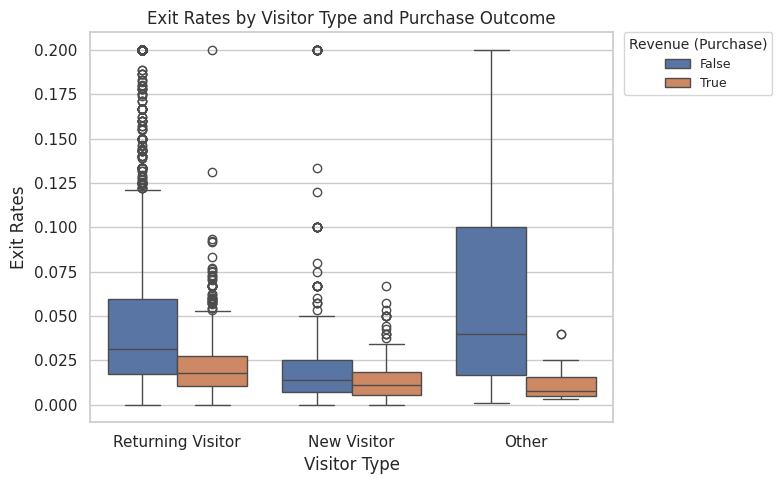

```python
# Make a clean label column (no underscores)
df = df.copy()
df["VisitorType_clean"] = df["VisitorType"].str.replace("_", " ", regex=False)

plt.figure(figsize=(8, 5))

ax = sns.boxplot(
    data=df,
    x="VisitorType_clean", y="ExitRates",
    hue="Revenue",
    linewidth=1
)

ax.set_title("Exit Rates by Visitor Type and Purchase Outcome")
ax.set_xlabel("Visitor Type")
ax.set_ylabel("Exit Rates")

# Move legend outside so it doesn't overlap the plot
handles, labels = ax.get_legend_handles_labels()
ax.legend(
    handles, labels,
    title="Revenue (Purchase)",
    loc="upper left",
    bbox_to_anchor=(1.02, 1.0),
    borderaxespad=0.0,
    fontsize=9,
    title_fontsize=10,
    frameon=True
)

plt.tight_layout()
plt.show()
```

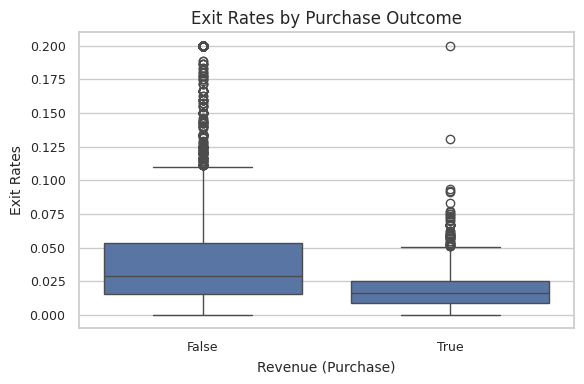

```python
plt.figure(figsize=(6, 4))

ax2 = sns.boxplot(
    data=df,
    x="Revenue", y="ExitRates",
    linewidth=1
)

ax2.set_title("Exit Rates by Purchase Outcome")
ax2.set_xlabel("Revenue (Purchase)", fontsize=10)   # smaller x-axis label
ax2.set_ylabel("Exit Rates", fontsize=10)           # smaller y-axis label

# (optional) also shrink tick-label font sizes
ax2.tick_params(axis='both', labelsize=9)

plt.tight_layout()
plt.show()
```

- **Explain why you consider this plot relevant to address your question or to explore the data.**  
  This boxplot compares `ExitRates` across `VisitorType` and purchase outcome (`Revenue`), so it directly explores whether exit behaviour and visitor type are related to purchasing. The simpler boxplot of `ExitRates` by `Revenue` alone provides a cleaner check of the overall difference in exit behaviour between purchasing and non-purchasing sessions.
- **Interpret briefly the results obtained.**  
  For returning visitors and “other” visitors, purchasing sessions (`Revenue = True`) tend to have clearly lower exit rates than non-purchasing sessions, while for new visitors the distributions of exit rates overlap more and the difference is less visually pronounced. In the simpler plot (exit rates vs revenue only), sessions with `Revenue = True` still show a lower median exit rate and a slightly tighter spread, but there is noticeable overlap between the two groups, suggesting that a formal statistical test would be needed to confirm the effect.
- **What do you learn from your visualization?**  
  Overall, ExitRates appears to be an informative predictor of purchase behaviour among different visitor types, with lower exit rates associated with a higher chance of generating revenue. The strong skew and many outliers in exit rates also signal potential modelling challenges (e.g., non-normality) and suggest that later analyses may need transformations or robust statistical testing to draw firm conclusions.

## Section 4: Method and Plan

- **Planned method.** I plan to fit a logistic regression model with `Revenue` (purchase vs no purchase) as the binary response, using engagement variables such as `PageValues`, `ExitRates`, `BounceRates`, `ProductRelated`, and the corresponding duration counts, along with categorical predictors like `VisitorType`, `Weekend`, and `Month`.
- **Why this method is appropriate.** Logistic regression is designed for binary outcomes and lets me estimate how each predictor is associated with the log-odds of a purchase, which matches my goal of identifying factors related to purchase intention and their direction and relative strength.
- **Key assumptions.** The model assumes that individual sessions are independent and that the log-odds of purchase change approximately linearly with each continuous predictor. It also assumes no extreme multicollinearity among predictors and that there is no complete separation of the outcome by any single variable.
- **Potential limitations or weaknesses.** Logistic regression only captures linear effects on the log-odds scale and may miss complex non-linear relationships or interactions between variables. Class imbalance (only a minority of sessions end in a purchase) can lead to poor calibration or biased classification unless we adjust the model. In addition, unmeasured factors (such as marketing campaigns or user history) may confound some associations, so results should be interpreted as associations rather than causal effects.

## Section 5: Computational Code and Output

Below I implement the logistic regression model described in Section 4 using selected behavioural and categorical variables to predict whether a session results in revenue. I report a single summary table of estimated coefficients and odds ratios for the predictors.

```python
from sklearn.model_selection import train_test_split
from sklearn.preprocessing import StandardScaler
from sklearn.linear_model import LogisticRegression
from sklearn.metrics import accuracy_score

# -----------------------------
# 1. Design matrix and outcome
# -----------------------------
# Numeric predictors (engagement / intent variables)
num_features = [
    "PageValues",
    "ExitRates",
    "BounceRates",
    "ProductRelated",
    "ProductRelated_Duration",
    "Administrative",
    "Administrative_Duration",
    "Informational",
    "Informational_Duration",
    "SpecialDay"
]

# Categorical predictors
cat_features = ["VisitorType", "Weekend", "Month", "TrafficType"]

# Subset and one-hot encode categorical variables
X_num = df[num_features].copy()
X_cat = pd.get_dummies(df[cat_features], drop_first=True)

X = pd.concat([X_num, X_cat], axis=1)
y = df["Revenue"].astype(int)  # 1 = purchase, 0 = no purchase

# -----------------------------
# 2. Train/test split + scaling
# -----------------------------
X_train, X_test, y_train, y_test = train_test_split(
    X, y, test_size=0.2, random_state=123, stratify=y
)

scaler = StandardScaler()
X_train_scaled = scaler.fit_transform(X_train)
X_test_scaled = scaler.transform(X_test)

# -----------------------------
# 3. Fit logistic regression
# -----------------------------
log_reg = LogisticRegression(
    max_iter=1000,
    class_weight="balanced",   # help with class imbalance
    solver="lbfgs"
)
log_reg.fit(X_train_scaled, y_train)

# -----------------------------
# 4. Coefficient + odds-ratio table
# -----------------------------
coef = log_reg.coef_[0]

coef_table = (
    pd.DataFrame({
        "Predictor": X.columns,
        "Coef_log_odds": coef,
        "Odds_ratio": np.exp(coef),
    })
    .assign(
        Abs_log_odds=lambda d: d["Coef_log_odds"].abs()
    )
    .sort_values(by="Abs_log_odds", ascending=False)
)

# Show only one table (top 12 predictors by |log-odds|, i.e. most impactful)
print(coef_table[["Predictor", "Coef_log_odds", "Odds_ratio"]].head(12))

# Generate predictions on the scaled test set and compute the classification accuracy
y_pred = log_reg.predict(X_test_scaled)
test_acc = accuracy_score(y_test, y_pred)
print(f"Test accuracy: {test_acc:.3f}")
```

```
                        Predictor  Coef_log_odds  Odds_ratio
0                      PageValues       2.348970   10.474772
1                       ExitRates      -0.540003    0.582747
19                      Month_May      -0.417863    0.658452
18                      Month_Mar      -0.336200    0.714480
14                      Month_Dec      -0.244307    0.783247
2                     BounceRates      -0.234259    0.791157
4         ProductRelated_Duration       0.230971    1.259823
15                      Month_Feb      -0.172844    0.841269
20                      Month_Nov       0.145695    1.156843
13  VisitorType_Returning_Visitor      -0.112436    0.893654
5                  Administrative       0.110465    1.116797
21                      Month_Oct      -0.082258    0.921034
Test accuracy: 0.866
```

The logistic regression model attains a test accuracy of about 86.6%, suggesting that the selected behavioural and contextual variables are reasonably effective for predicting purchases. PageValues remains by far the dominant predictor (odds ratio ≈ 10.5), indicating that sessions with higher page value scores are much more likely to generate revenue. The largest negative effects come from ExitRates, BounceRates, several month indicators (e.g., May, March, December, February, October), and VisitorType_Returning_Visitor, all of which have odds ratios below 1 and are associated with reduced purchase odds relative to their respective reference categories. In contrast, ProductRelated_Duration, Administrative, and Month_Nov have more modest positive associations (odds ratios slightly above 1), and many remaining predictors have effects close to neutral, so a fuller analysis with confidence intervals or significance tests would be useful to confirm which variables are truly important.